# practice-midterm-with-solution

Introduction to Data Science  
Winter 2018

## Practice Midterm Exam

- You have 45 minutes to complete the exam
- The exam is closed book, closed notes, closed computer, closed calculator, except one hand-written 8.5” × 11” crib sheet of your own creation and the official study guide provided with the exam.
- Mark your answers **on the exam itself**. We will **not** grade answers written on scratch paper.

**Last name**

====================================================

**First name**

====================================================

**Student Id number**

====================================================

**Email**

====================================================

**Name of the person to your right**

====================================================

**Name of the person to your left**

====================================================

**All the work on this exam is my own**  
(Please sign)

====================================================

```python
# Import modules

import numpy as np
from datascience import *
from datascience_extensions import *
import seaborn as sns
sns.set_style("whitegrid")
%matplotlib inline
```

```python
color = np.array(["red", "blue", "blue", "red", "green"])
brand = np.array(["Volvo", "Chevy", "Volvo", "Volvo", "Chevy"])
cars = Table().with_columns("color", color, "brand", brand)
cars
```

| color | brand |
| --- | --- |
| red | Volvo |
| blue | Chevy |
| blue | Volvo |
| red | Volvo |
| green | Chevy |

**Problem 1** (5 points)

Calculate (by hand) and write down the pivot table cars.pivot("color", "brand")

```python
cars.pivot("color", "brand")
```

| brand | blue | green | red |
| --- | --- | --- | --- |
| Chevy | 1 | 1 | 0 |
| Volvo | 1 | 0 | 2 |

**Problem 2** (5 points)

Write a Python expression that calculates the number of Volvos

```python
cars.where("brand", are.equal_to("Volvo")).num_rows
```

```
3
```

**Problem 3** (5 points)

Write a Python expression that calculates the number of blue Volvos

```python
cars.where("brand", are.equal_to("Volvo")).where("color", are.equal_to ("blue")).num_rows
```

```
1
```

**Problem 4** (10 points)

Suppose tab is a table with all numerical columns. Write a function row_means(tab) that returns an array containg the means of all the rows.

```python
def row_means(tab):
    row_sums = tab.column(0)
    nc = tab.num_columns
    if nc >= 1:
        for i in np.arange(1, nc):
            row_sums = row_sums + tab.column(i)
    row_means = row_sums / nc
    return row_means

tab = Table().with_columns("x", [1, 2 ,3], "y", [4, 5, 6])
row_means(tab)
```

```
array([ 2.5,  3.5,  4.5])
```

**Problem 5** (10 points)

Printed below are the first three rows of a table. The column labels should be self explanatory.

Write an expression that calculates the difference between the average birth weights of children of non smokers and children of smokers.

```python
baby = Table().read_table("baby.csv")
baby.show(3)
```

| Birth Weight | Gestational Days | Maternal Age | Maternal Height | Maternal Pregnancy Weight | Maternal Smoker |
| --- | --- | --- | --- | --- | --- |
| 120 | 284 | 27 | 62 | 100 | False |
| 113 | 282 | 33 | 64 | 135 | False |
| 128 | 279 | 28 | 64 | 115 | True |

... (1171 rows omitted)

```python
np.mean(baby.where("Maternal Smoker", are.equal_to(False)).column("Birth Weight")) \
- np.mean(baby.where("Maternal Smoker", are.equal_to(True)).column("Birth Weight"))
```

```
9.2661425720249184
```

**Problem 6** (10 points)

Write code that calculates the number of babies for which both Birth Weight and Maternal Pregnancy Weight are above the mean.

```python
bw_mean = np.mean(baby.column("Birth Weight"))
mpw_mean = np.mean(baby.column("Maternal Pregnancy Weight"))
baby.where("Birth Weight", are.above(bw_mean)).\
  where("Maternal Pregnancy Weight", are.above(mpw_mean)).num_rows
```

```
295
```

**Problem 7** (10 points)

Below is a histogram of Birth Weight. Roughly, what is the percentage of babies with birth weight below 100oz.

```python
# About (0.5 + 0.1) * 20% ~ 12%

baby.where("Birth Weight", are.below(100)).num_rows / baby.num_rows
```

```
0.1303236797274276
```

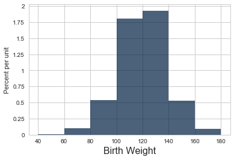

```python
baby.hist("Birth Weight", bins = np.arange(40, 200, 20))
```